# Exercise 6

Kyle M. Lang

Fundamental Techniques in Data Science with R

We will use the following packages in this practical:

```r
library(dplyr)
library(magrittr)
library(ggplot2)
```

This practical begins with the same question as the previous practical. After you fit the same four models as last time, however, you will move on to checking the assumptions of the fitted models.

# 1 Fitting Linear Models

## 1.1

**Fit the following linear models using the `anscombe` data:**

- Predict `y1` from `x1`
  - Stored the results in an object called `fit1`
- Predict `y2` from `x2`
  - Stored the results in an object called `fit2`
- Predict `y3` from `x3`
  - Stored the results in an object called `fit3`
- Predict `y4` from `x4`
  - Stored the results in an object called `fit4`

```r
fit1 <- lm(y1 ~ x1, data = anscombe)
fit2 <- lm(y2 ~ x2, data = anscombe)
fit3 <- lm(y3 ~ x3, data = anscombe)
fit4 <- lm(y4 ~ x4, data = anscombe)
```

# 2 Checking Assumptions

## 2.1 Model 1

**Inspect the assumptions of the first model**

Use the `plot()` function to generate diagnostic plots for `fit1`.

- What are your conclusions with respect to the tenability of the model assumptions?

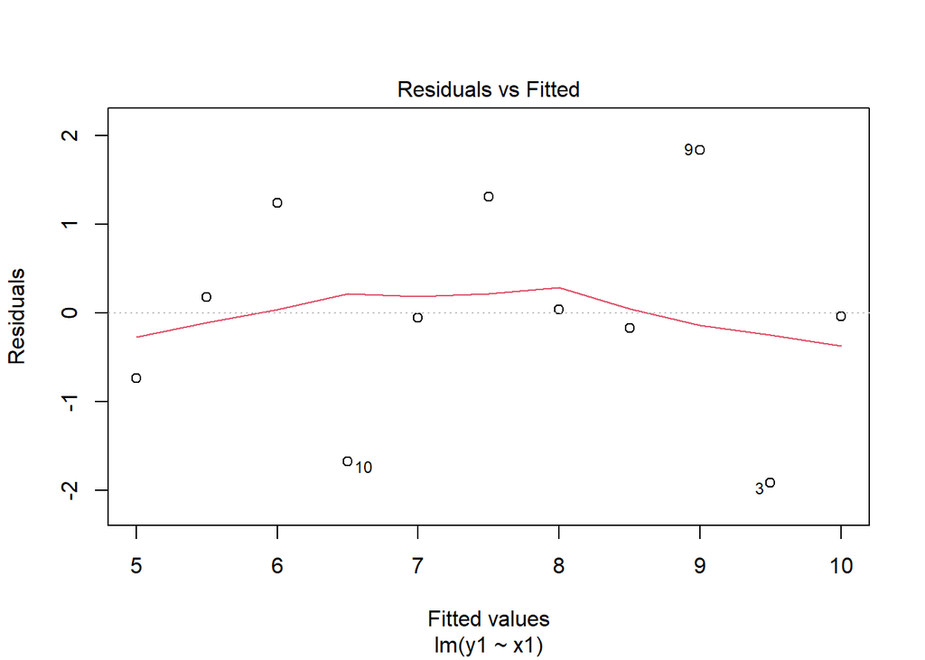

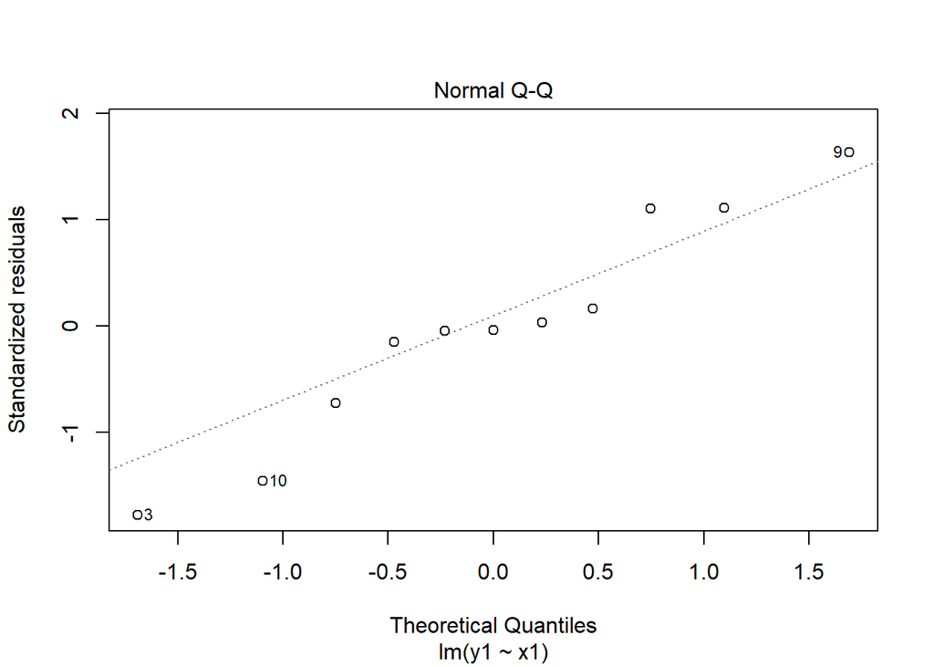

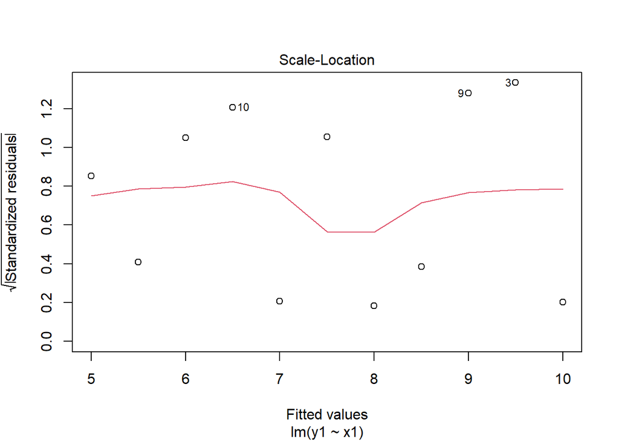

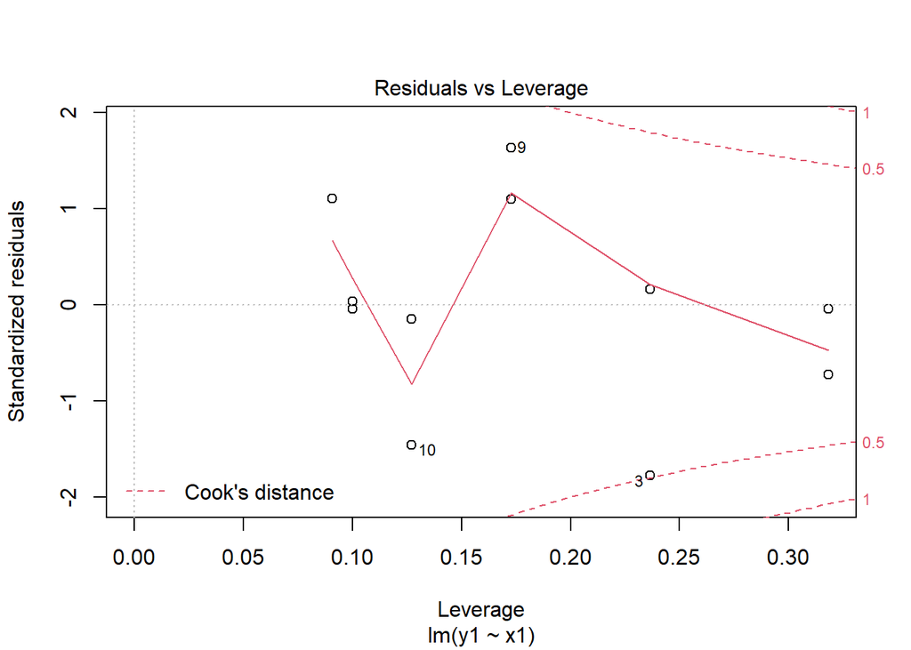

```r
plot(fit1)
```

The assumptions of the linear model seem to be satisfied.

- The data follow a linear trend. The loess curve shows some deviations from perfect linearity, but there are only 11 points. So, this slight deviation is not a problem.
- Taking the small sample size into account, I would argue that the residuals seem normally distributed based on the *Normal Q-Q* plot.
- The residual variance seems constant over the level of the fitted values (i.e. homoscedastic residual variance) as seen in the *Residuals vs. Fitted* plot and the *Scale-Location* plot. The dip in the *Scale-Location* plot can easily be explained by the small sample size, so the deviation shouldn’t be taken too seriously.
- No cases seem particularly influentially according to leverage or Cook’s distance. Although, Case 3 should probably be investigated a bit more closely.

## 2.2 Model 2

**Inspect the assumptions of the second model**

Use the `plot()` function to generate diagnostic plots for `fit2`.

- What are your conclusions with respect to the tenability of the model assumptions?

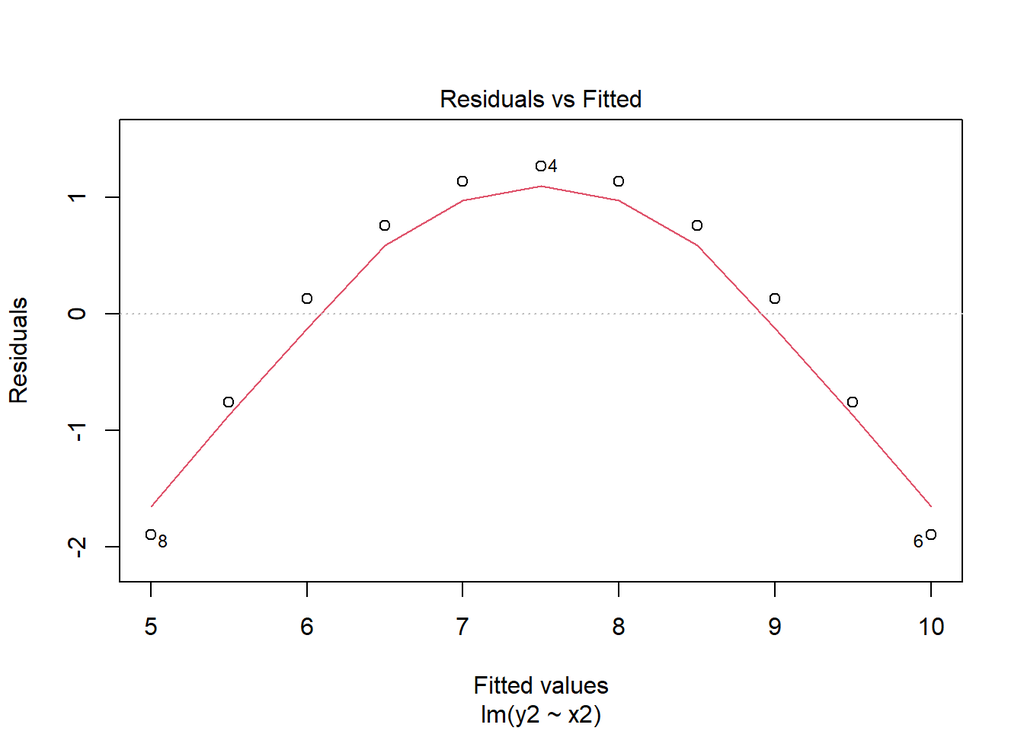

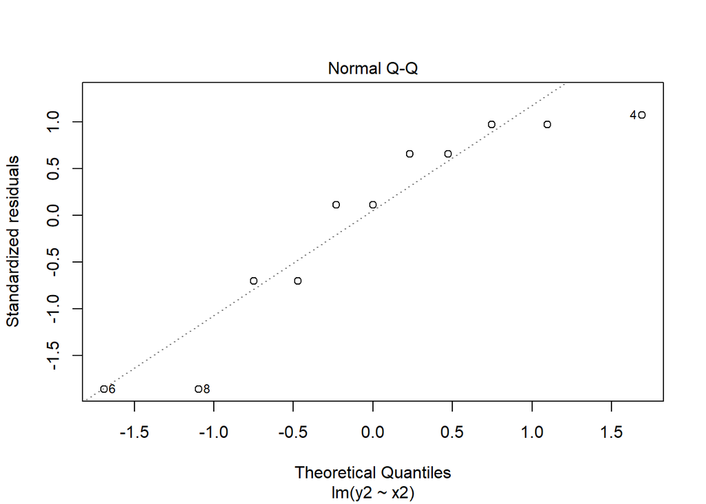

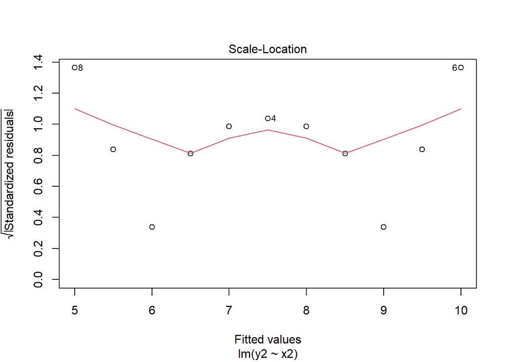

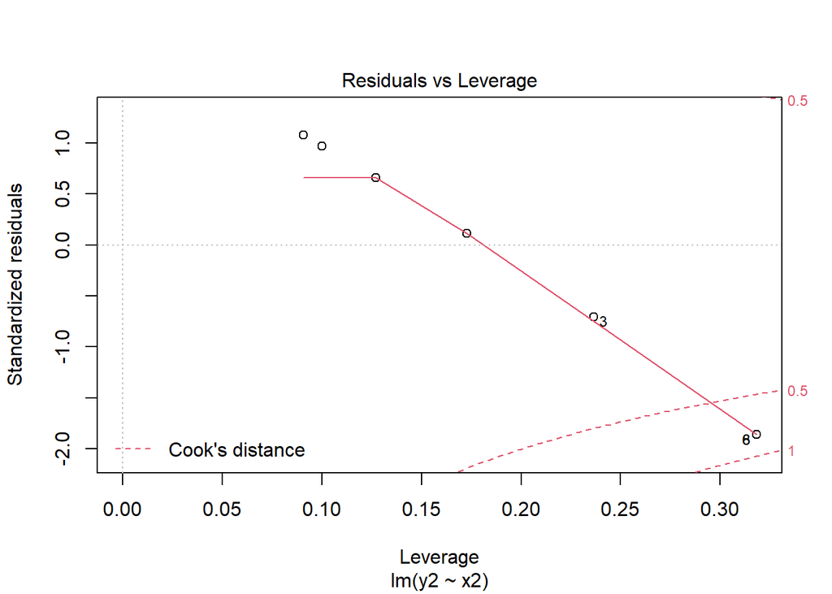

```r
plot(fit2)
```

The assumption of linearity is clearly violated here.

- The data do not follow a linear trend. There is a clear curvilinear trend in the residual plot.
- According to the *Normal Q-Q* plot, the residuals seem not to be normally distributed, especially in the tails.
- Cases 6 and 8 seem potentially influential, the have relatively large Cook’s distances (i.e., greater than 0.5).

## 2.3 Model 3

**Inspect the assumptions of the third model**

Use the `plot()` function to generate diagnostic plots for `fit3`.

- What are your conclusions with respect to the tenability of the model assumptions?

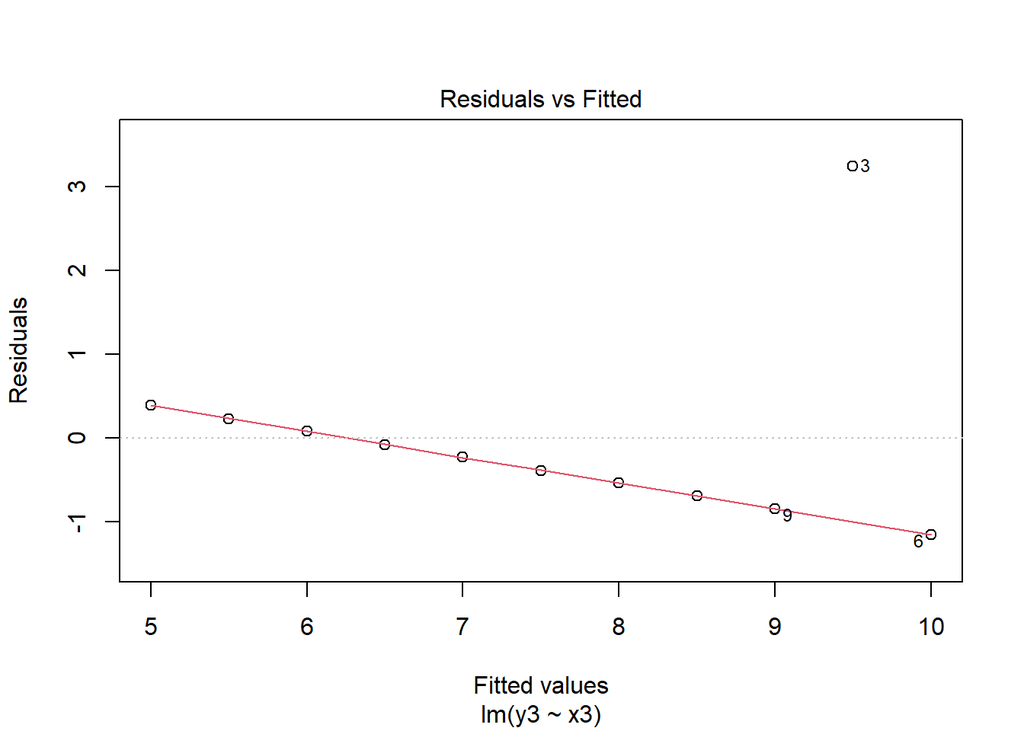

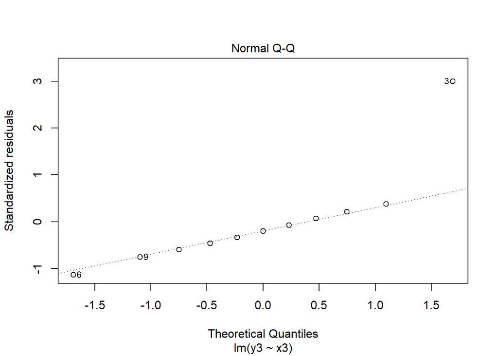

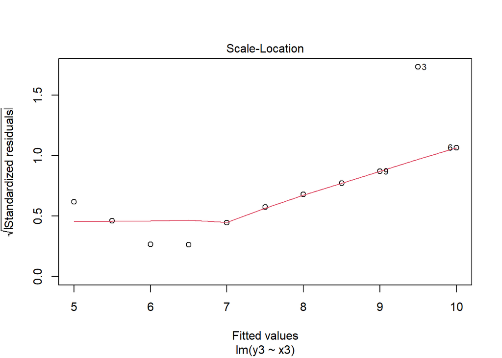

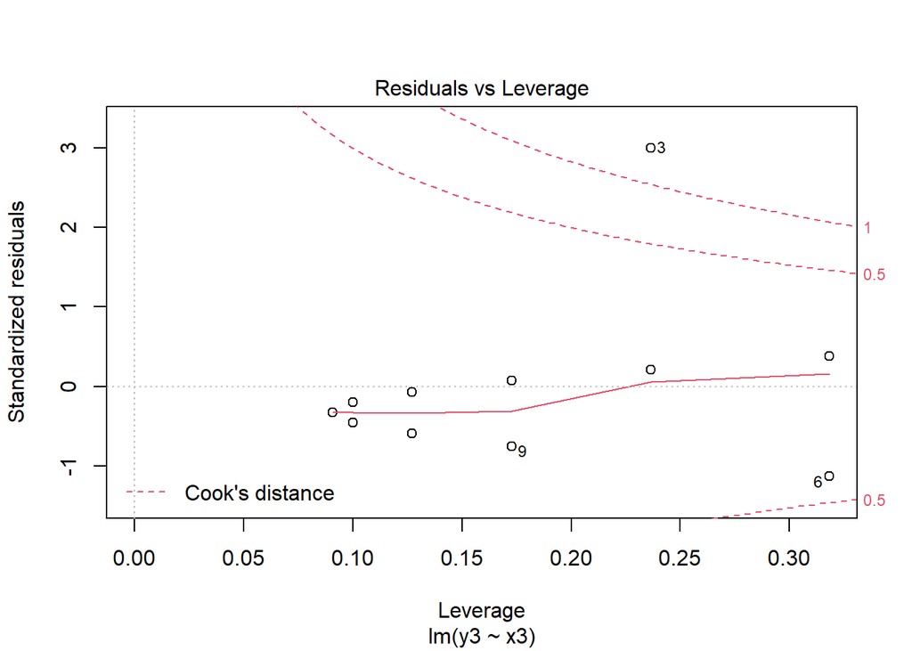

```r
plot(fit3)
```

These data clearly suffer from one severe outlier.

- The data follow a perfect linear trend, except for Case 3.
- The residuals are perfectly normal, except for Case 3.
- Case 3 seems quite influential. Case 3 has a very large residual, so its Cook’s distance is also quite large (i.e., greater than 1).

tl;dr: Case 3 is why we can’t have nice things.

## 2.4 Model 4

**Inspect the assumptions of the fourth model**

Use the `plot()` function to generate diagnostic plots for `fit4`.

- What are your conclusions with respect to the tenability of the model assumptions?

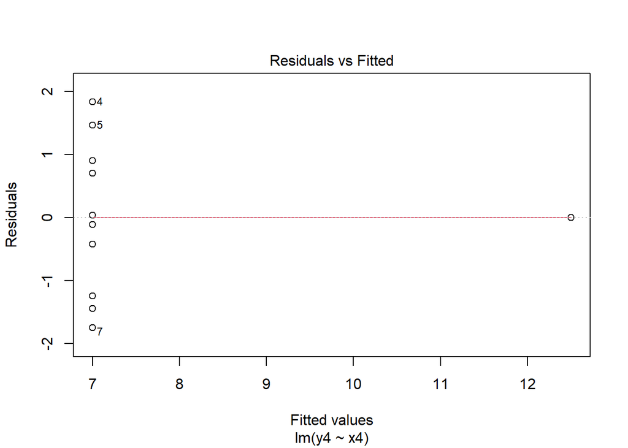

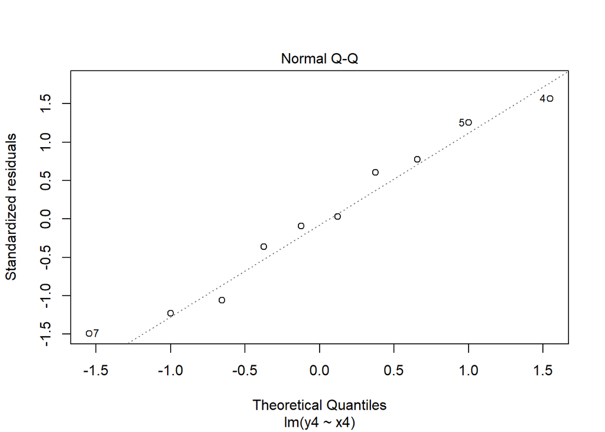

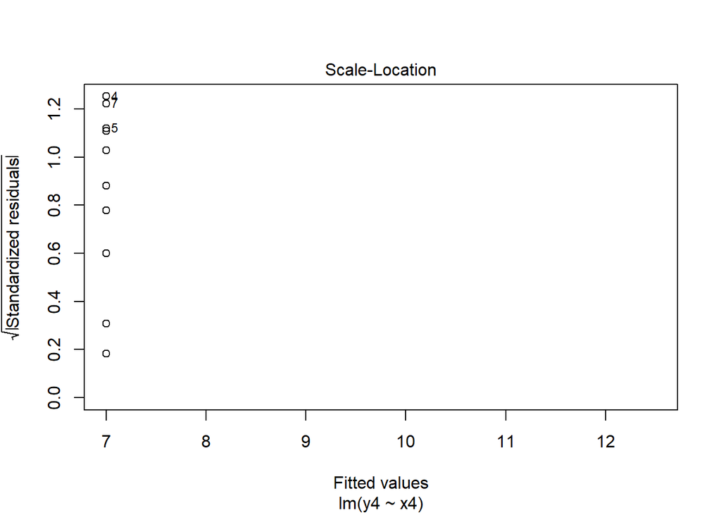

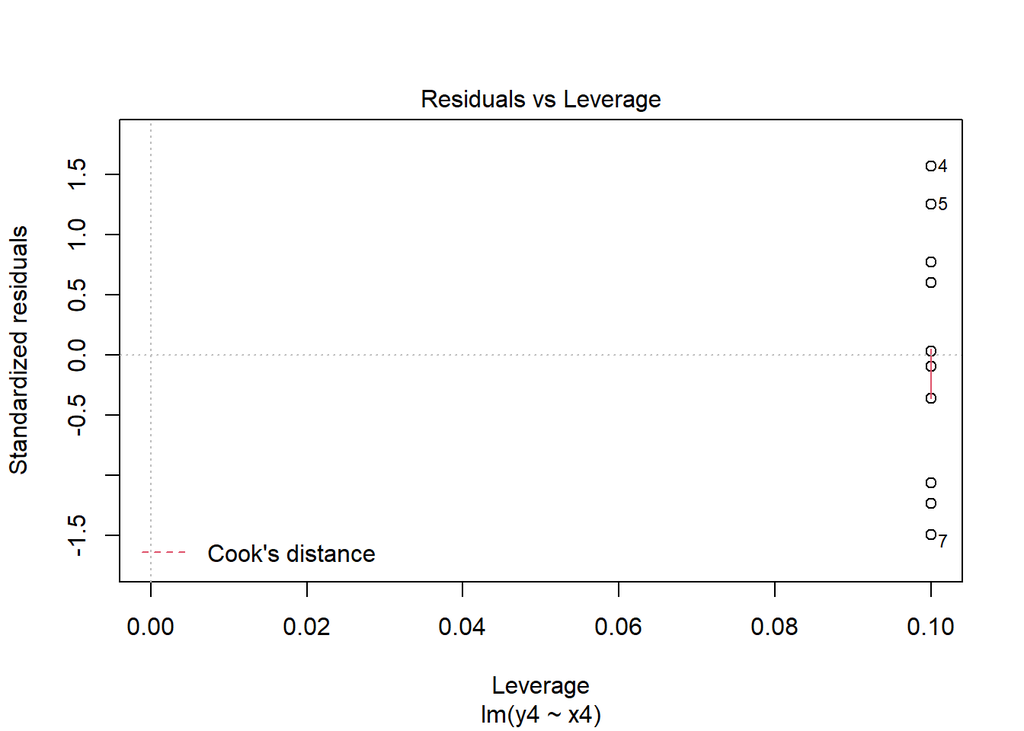

```r
plot(fit4)
```

`x4` is (nearly) constant, and the data also suffer from a high-leverage point.

- The first plot clearly shows a single point (Case 8) with very high leverage.
- Other than Case 8, `x4` is a constant (i.e., `x4` takes the same value for all values of `y4`).
- Case 8 has a leverage of 1 (i.e., the maximum possible value), so this case is dropped from all but the first plot.
  - The remaining plots are not accurate representations of the data.
  - We can only use these plots to infer how the data would behave if Case 8 were excluded.

End of Exercise 6